# Pokemón Data Analysis

A intenção dessa Análise Exploratória é trabalhar com a Estatística Descritiva. Tem o intuito de descrever e até mesmo coletar algumas informações e curiosidades sobre o dataset de Pokemons.

Para isso, além das técnicas para manipulação dos dados, seguirei algumas premissas que me guiarão nessa busca:

1. Qual é a quantidade total de Pokémons neste dataset?
2. Quantos Pokemóns foram lançados em cada geração?
3. Qual é a distribuição dos Pokémons por tipo_1 (predominante)?
4. Qual é a distribuição dos Pokémons por tipo_2 em função do tipo_1?
5. Em cada GERAÇÃO, identificar o Pokémon: i. mais alto (height_m);  
   ii. mais pesado (weight_kg);  
   iii. maior HP (hp);  
   iv. maior ataque (attack);  
   v. maior defesa (defense);  
   vi. mais rápido (speed);

```python
# Importação das bibliotecas para a manipulação e visualização dos dados.

import pandas as pd
import numpy as np
from matplotlib import pyplot as plt
import seaborn as sns
from skimage.io import imread
%matplotlib inline
```

```python
# Abertura do banco de dados e filtro das colunas que importam.

pokedata = pd.read_csv('pokedex_(Update_04.21).csv')
pokedata = pokedata.drop(columns = ['Unnamed: 0'])
pkcolumns = ['pokedex_number', 'name', 'german_name',
             'japanese_name', 'generation', 'status', 'species',
             'type_number', 'type_1', 'type_2', 'height_m',
             'weight_kg', 'hp', 'attack', 'defense',
             'sp_attack', 'sp_defense', 'speed', 'catch_rate']
pokedata = pokedata[pkcolumns]
pokedata.head()
```

|  | pokedex_number | name | german_name | japanese_name | generation | status | species | type_number | type_1 | type_2 | height_m | weight_kg | hp | attack | defense | sp_attack | sp_defense | speed | catch_rate |
| --- | --- | --- | --- | --- | --- | --- | --- | --- | --- | --- | --- | --- | --- | --- | --- | --- | --- | --- | --- |
| 0 | 1 | Bulbasaur | Bisasam | フシギダネ (Fushigidane) | 1 | Normal | Seed Pokémon | 2 | Grass | Poison | 0.7 | 6.9 | 45 | 49 | 49 | 65 | 65 | 45 | 45.0 |
| 1 | 2 | Ivysaur | Bisaknosp | フシギソウ (Fushigisou) | 1 | Normal | Seed Pokémon | 2 | Grass | Poison | 1.0 | 13.0 | 60 | 62 | 63 | 80 | 80 | 60 | 45.0 |
| 2 | 3 | Venusaur | Bisaflor | フシギバナ (Fushigibana) | 1 | Normal | Seed Pokémon | 2 | Grass | Poison | 2.0 | 100.0 | 80 | 82 | 83 | 100 | 100 | 80 | 45.0 |
| 3 | 3 | Mega Venusaur | Bisaflor | フシギバナ (Fushigibana) | 1 | Normal | Seed Pokémon | 2 | Grass | Poison | 2.4 | 155.5 | 80 | 100 | 123 | 122 | 120 | 80 | 45.0 |
| 4 | 4 | Charmander | Glumanda | ヒトカゲ (Hitokage) | 1 | Normal | Lizard Pokémon | 1 | Fire | NaN | 0.6 | 8.5 | 39 | 52 | 43 | 60 | 50 | 65 | 45.0 |

## 1. Qual é a quantidade total de Pokémons neste dataset?

```python
# Indica se há repetições no dataset

pokedata.duplicated().value_counts()
pkmcount = pokedata.name.nunique()

print(f'\nNeste dataset foram encontrados {pkmcount} pokémons (sem repetições).')
```

```
Neste dataset foram encontrados 1045 pokémons (sem repetições).
```

## 2. Quantos Pokemóns foram lançados em cada geração?

Após avaliar o dataset, foi possível notar que alguns Pokemóns das primeiras gerações ganharam outras evoluções a partir das 6 e 7 gerações, porém constam como se fossem das primeiras. Dessa maneira as gerações desses Pokémons foram alteradas para as gerações corretas

```python
# Atribuindo a geração correta aos Pokémons

pokedata.loc[pokedata['name'].str.contains('Mega'), 'generation'] = 6
pokedata.loc[pokedata['name'].str.contains('Alolan'), 'generation'] = 7
pokedata.loc[pokedata['name'].str.contains('Galarian'), 'generation'] = 7
pokedata.loc[pokedata['name'].str.contains('Partner'), 'generation'] = 7
```

```python
# Contando a quantidade de Pokémons através da função 'value_counts'

pkbygen = pokedata.generation.value_counts().sort_index()

for i, j in enumerate(pkbygen):
    print(f'Na geração {i + 1} foram lançados {j} Pokémons')
```

```
Na geração 1 foram lançados 151 Pokémons
Na geração 2 foram lançados 99 Pokémons
Na geração 3 foram lançados 143 Pokémons
Na geração 4 foram lançados 116 Pokémons
Na geração 5 foram lançados 165 Pokémons
Na geração 6 foram lançados 133 Pokémons
Na geração 7 foram lançados 139 Pokémons
Na geração 8 foram lançados 99 Pokémons
```

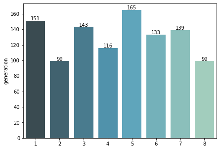

```python
# Impressão de um barplot (gráfico de barras) de forma a representar a quantidade de pokémons por geração,
# neste caso, desde a 1ª até a 8ª geração

plt.figure(figsize=(7, 5))
pkg = sns.barplot(x = pkbygen.index, y = pkbygen, palette = 'GnBu_d')
for i in pkg.patches:
    pkg.annotate("%.0f" % i.get_height(), # retorna a altura das barras de acordo com as informações nos patches
                 (i.get_x() + i.get_width() / 2, i.get_height()), # get_x = altura, get_y = largura
                  ha = 'center', # alinhamento do texto
                  va = 'baseline', # alinhamento vertical
                  color = 'black',
                  xytext = (0, 1),
                  textcoords = 'offset points',
                  fontsize = 10
                 )
```

## 3. Qual é a distribuição dos Pokémons por tipo_1 (predominante)?

```python
# Separando os tipos de pokémons em um novo dataframe menor com as colunas 'type_1' e
# 'type_2'. Além disso, os valores 'NaN' foram substituídos por valores em branco ''.

types = pokedata[['type_1', 'type_2']]
types = types.fillna('')
```

```python
# Contagem da distribuição dos Pokémons de acordo com o tipo predominante (type_1)
# Foram separados por duas variáveis x e y

x = types.type_1.value_counts().index.tolist()
y = types.type_1.value_counts()
```

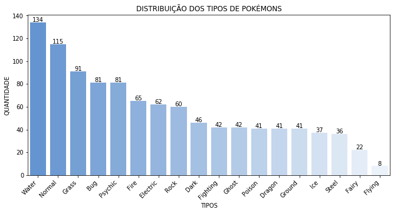

```python
# Plot da distribuição

fig, ax = plt.subplots(figsize = (11,5))
palette = sns.light_palette((250, 75, 60), n_colors = len(x), input="husl", reverse = True)

pkdist = sns.barplot(x=x, y=y, palette=palette)
for i in pkdist.patches:
    pkdist.annotate("%.0f" % i.get_height(), # retorna a altura das barras de acordo com as informações nos patches
                 (i.get_x() + i.get_width() / 2, i.get_height()), # get_x = altura, get_y = largura
                  ha = 'center', # alinhamento do texto
                  va = 'baseline', # alinhamento vertical
                  color = 'black',
                  xytext = (0, 1),
                  textcoords = 'offset points',
                  fontsize = 10
                 )
plt.title('DISTRIBUIÇÃO DOS TIPOS DE POKÉMONS', fontsize = 12)
plt.xticks(rotation = 45, horizontalalignment = 'right')
pkdist.set(xlabel = 'TIPOS', ylabel = 'QUANTIDADE')
plt.show()
```

## 4. Qual é a distribuição dos Pokémons por tipo_2 em função do tipo_1?

```python
# Na coluna 'type_2', onde foram inseridos valores em branco (''), foram inseridos
# os valores predominantes. Como há Pokémons que não possuem mais de um tipo, foi
# mantido o tipo predominante como segundo tipo.

for i, j in enumerate(types.type_2):
    if j == '':
        types['type_2'][i] = types['type_1'][i]
    else:
        continue

# Construção de um dicionário para separação dos tipos secundários (type_2) e montagem dos gráficos

var = {}
pokevar = pokedata.type_1.value_counts().index.sort_values()
for i in pokevar:
    var[f'{i}'] = types[(types['type_1'] == i)]
```

```python
# Para deixar o gráfico visualmente mais bonito, separei algumas cores condizentes ao tipo de Pokémon

dic = {'Bug': [65, 86, 65], 'Dark' : [63, 0, 27], 'Dragon': [150, 75, 60],
      'Electric' : [75, 99, 90], 'Fairy' : [20, 90, 75], 'Fighting' : [40, 86, 65],
      'Fire' : [13, 99, 50], 'Flying' : [250, 95, 80], 'Ghost' : [350, 95, 40],
      'Grass' : [130, 90, 65], 'Ground' : [63, 86, 65], 'Ice' : [250, 99, 60],
      'Normal' : [20, 90, 85], 'Poison' : [350, 95, 40], 'Psychic' : [50, 86, 60],
      'Rock' : [63, 0, 40], 'Steel' : [63, 0, 60], 'Water' : [250, 75, 60]}

colorspal = []

for i in dic.items():
    color = sns.light_palette((i[1]), n_colors = len(var[i[0]]['type_2'].value_counts()), input="husl", reverse = True)
    colorspal.append(color)
```

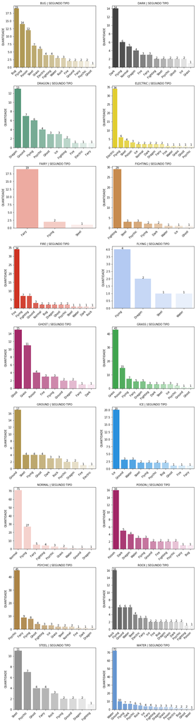

```python
# Geração de um loop for para coleta de todos as informações obtidas no dicionário. Nestes
# gráficos são demonstrados o tipo predominante e, em seguida, o tipo secundário dos pokémons

plt.figure(figsize = (12, 48))

for i, j in enumerate(pokevar):
    plt.subplot(9, 2, i + 1)
    g = sns.countplot('type_2', data = var[f'{j}'], order = var[f'{j}'].type_2.value_counts().index, palette = colorspal[i])
    for i in g.patches:
        g.annotate("%.0f" % i.get_height(), # retorna a altura das barras de acordo com as informações nos patches
                     (i.get_x() + i.get_width() / 2, i.get_height()), # get_x = altura, get_y = largura
                      ha = 'center', # alinhamento do texto
                      va = 'baseline', # alinhamento vertical
                      color = 'black', #
                      xytext = (0, 1),
                      textcoords = 'offset points',
                      fontsize = 10
                     )
    plt.title(f'{j.upper()} | SEGUNDO TIPO', fontsize = 10)
    g.set(xlabel = '', ylabel = 'QUANTIDADE')
    plt.xticks(rotation = 45, horizontalalignment = 'right', fontsize = 10)
plt.subplots_adjust(hspace=.3)
plt.show()
```

## 5. Em cada GERAÇÃO, identificar o Pokémon:

```python
# Criação de uma função para coleta dos dados

def pokelytics(col = 'hp'):
    pdex = []
    pokelist = []
    pokenames = []

    print('='*70)
    print('{:^70}'.format(f'MAIORES VALORES POR GERAÇÃO: {col.upper()}'))
    print('='*70)
    print('|{:^16}|'.format('POKEDEX_NUMBER'), end = '')
    print('{:^25}|'.format('NOME'), end = '')
    print('{:^12}|'.format('GERAÇÃO'), end = '')
    print('{:^12}|'.format(col.upper()))

    # Busca e impressão das características de acordo com geração
    for i in range(1, 9, 1):
        hgen = pokedata[pokedata['generation'] == i][['pokedex_number','name', col]].sort_values(by = [col], ascending = False)
        hgen_max = hgen.loc[hgen[col].idxmax()]
        pdex.append(hgen_max[0])
        pokelist.append(hgen_max.values[2])
        pokenames.append(hgen_max[1])

        print('|{:^16}|'.format(hgen_max.values[0]), end = '')
        print('{:^25}|'.format(hgen_max.values[1].upper()), end = '')
        print('{:^12}|'.format(i), end = '')
        print('{:^12}|'.format(hgen_max.values[2]))

    # Impressão das imagens dos Pokémons
    hp = []
    for i in pdex:
        if i == 103 or i == 150 or i == 65:
            hp.append(imread(str(f'https://assets.pokemon.com/assets/cms2/img/pokedex/full/{i:03d}_f2.png')))
        else:
            hp.append(imread(str(f'https://assets.pokemon.com/assets/cms2/img/pokedex/full/{i:03d}.png')))

    fig = plt.figure(figsize = (15, 15))

    for i in range(len(hp)):
        fig.add_subplot((len(hp)/2), 2, i + 1)
        plt.imshow(hp[i])
        name = pokedata[pokedata['name'] == pokenames[i]]['name'].values[0]
        gen = pokedata[pokedata['name'] == pokenames[i]]['generation'].values[0]
        plt.title(f'{pokenames[i].upper()} | {col.upper()} {pokelist[i]} | Geração {gen}', fontsize = 10)
    plt.subplots_adjust(hspace=.3)
    plt.show()
```

### i. mais alto (height_m);

```
======================================================================
                MAIORES VALORES POR GERAÇÃO: HEIGHT_M
======================================================================
| POKEDEX_NUMBER |          NOME           |  GERAÇÃO   |  HEIGHT_M  |
|       95       |          ONIX           |     1      |    8.8     |
|      208       |         STEELIX         |     2      |    9.2     |
|      321       |         WAILORD         |     3      |    14.5    |
|      487       |  GIRATINA ORIGIN FORME  |     4      |    6.9     |
|      646       |      WHITE KYUREM       |     5      |    3.6     |
|      384       |      MEGA RAYQUAZA      |     6      |    10.8    |
|      103       |    ALOLAN EXEGGUTOR     |     7      |    10.9    |
|      890       |   ETERNATUS ETERNAMAX   |     8      |   100.0    |
```

[figure not shown]

```python
pokelytics(col = 'height_m')
```

### ii. mais pesado (weight_kg);

```
======================================================================
                MAIORES VALORES POR GERAÇÃO: WEIGHT_KG
======================================================================
| POKEDEX_NUMBER |          NOME           |  GERAÇÃO   | WEIGHT_KG  |
|      143       |         SNORLAX         |     1      |   460.0    |
|      208       |         STEELIX         |     2      |   400.0    |
|      383       |     PRIMAL GROUDON      |     3      |   999.7    |
|      487       | GIRATINA ALTERED FORME  |     4      |   750.0    |
|      644       |         ZEKROM          |     5      |   345.0    |
|      376       |     MEGA METAGROSS      |     6      |   942.9    |
|      790       |         COSMOEM         |     7      |   999.9    |
|      890       |        ETERNATUS        |     8      |   950.0    |
```

[figure not shown]

```python
pokelytics(col = 'weight_kg')
```

### iii. maior HP;

```
======================================================================
                   MAIORES VALORES POR GERAÇÃO: HP
======================================================================
| POKEDEX_NUMBER |          NOME           |  GERAÇÃO   |     HP     |
|      113       |         CHANSEY         |     1      |    250     |
|      242       |         BLISSEY         |     2      |    255     |
|      321       |         WAILORD         |     3      |    170     |
|      426       |        DRIFBLIM         |     4      |    150     |
|      594       |        ALOMOMOLA        |     5      |    165     |
|      718       | ZYGARDE COMPLETE FORME  |     6      |    216     |
|      799       |        GUZZLORD         |     7      |    223     |
|      890       |   ETERNATUS ETERNAMAX   |     8      |    255     |
```

[figure not shown]

```python
pokelytics(col = 'hp')
```

### iv. maior ataque (attack);

```
======================================================================
                 MAIORES VALORES POR GERAÇÃO: ATTACK
======================================================================
| POKEDEX_NUMBER |          NOME           |  GERAÇÃO   |   ATTACK   |
|      149       |        DRAGONITE        |     1      |    134     |
|      248       |        TYRANITAR        |     2      |    134     |
|      386       |   DEOXYS ATTACK FORME   |     3      |    180     |
|      409       |        RAMPARDOS        |     4      |    165     |
|      646       |      BLACK KYUREM       |     5      |    170     |
|      150       |      MEGA MEWTWO X      |     6      |    190     |
|      798       |         KARTANA         |     7      |    181     |
|      888       |  ZACIAN CROWNED SWORD   |     8      |    170     |
```

[figure not shown]

```python
pokelytics(col = 'attack')
```

### v. maior defesa;

```
======================================================================
                 MAIORES VALORES POR GERAÇÃO: DEFENSE
======================================================================
| POKEDEX_NUMBER |          NOME           |  GERAÇÃO   |  DEFENSE   |
|       91       |        CLOYSTER         |     1      |    180     |
|      213       |         SHUCKLE         |     2      |    230     |
|      377       |        REGIROCK         |     3      |    200     |
|      411       |        BASTIODON        |     4      |    168     |
|      563       |       COFAGRIGUS        |     5      |    145     |
|      306       |       MEGA AGGRON       |     6      |    230     |
|      805       |        STAKATAKA        |     7      |    211     |
|      890       |   ETERNATUS ETERNAMAX   |     8      |    250     |
```

[figure not shown]

```python
pokelytics(col = 'defense')
```

### vi. mais rápido;

```
======================================================================
                  MAIORES VALORES POR GERAÇÃO: SPEED
======================================================================
| POKEDEX_NUMBER |          NOME           |  GERAÇÃO   |   SPEED    |
|      101       |        ELECTRODE        |     1      |    150     |
|      169       |         CROBAT          |     2      |    130     |
|      386       |   DEOXYS SPEED FORME    |     3      |    180     |
|      492       |    SHAYMIN SKY FORME    |     4      |    127     |
|      617       |        ACCELGOR         |     5      |    145     |
|       65       |      MEGA ALAKAZAM      |     6      |    150     |
|      795       |        PHEROMOSA        |     7      |    151     |
|      894       |        REGIELEKI        |     8      |    200     |
```

[figure not shown]

```python
pokelytics(col = 'speed')
```